# Maps - Plot Universities across USA

## The Domain

IPEDS is the primary source of information on U.S Colleges, Universities, technical and vaccational institutions. The purpose of this report is to explore map visualization with the American University data.

## Dataset

Dataset has details about the universities and colleges in USA for year 2013. It has details of degrees’ offered,enrollment, graduation and fees and so on. Data set has university details along with their geo locations.

The dataset provided at https://public.tableau.com/en-us/s/resources. It is called “American University Data”. This is a smaller version of dataset available at https://nces.ed.gov/ipeds/Home/UseTheData.

## Maps

### University Location

Below map shows all colleges across states in USA. Each point in the map represents a college.

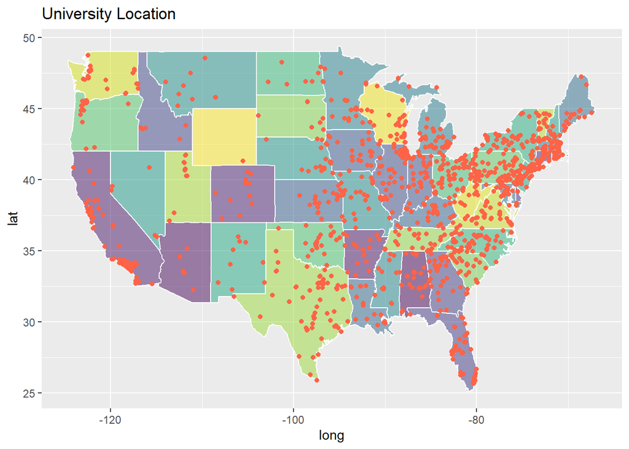

### Public&Private University Location

The figure below shows the location distribution of public and private universities.

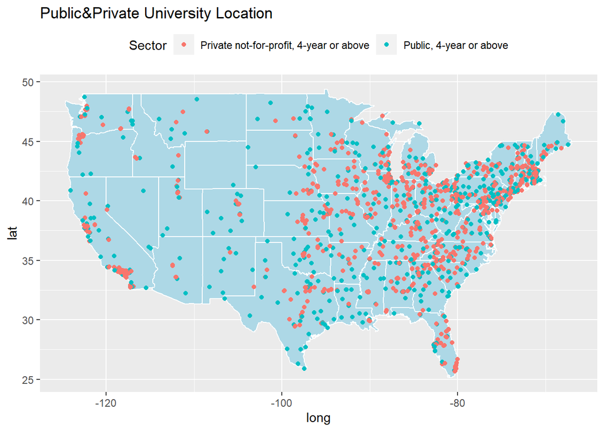

### American University Heat Map

The density heat map shows that universities are mainly concentrated in the eastern and coastal areas of the United States.

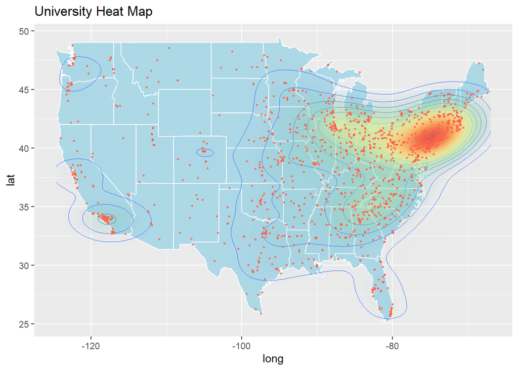

## University Statistics

The figure below shows the number of universities in each state. The larger the bubble, the greater the number of universities.

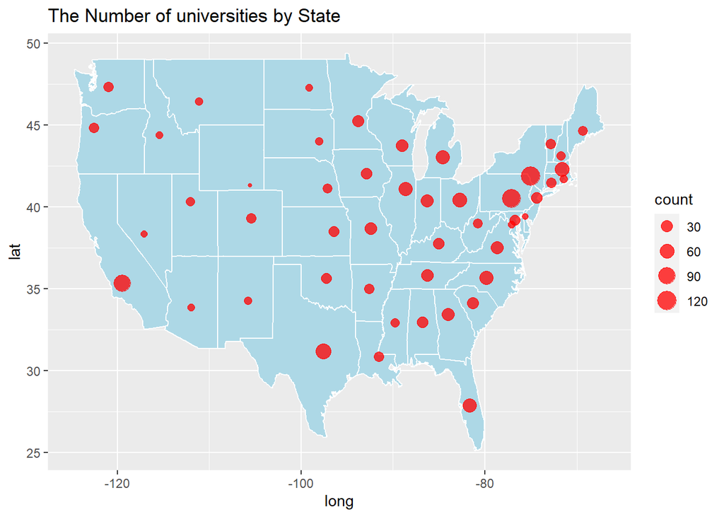